# Part I - (Used car dataset exploration)

## Bivariate Exploration

### Bivariate exploration on two numeric variables only

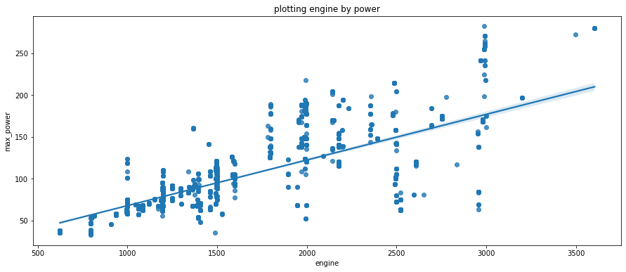

```python
#plotting the relationship between engine and the power in the dataset
ax = plt.subplots(figsize=(15, 6))
sns.regplot(data=car, x="engine", y='max_power')
plt.title('plotting engine by power');
```

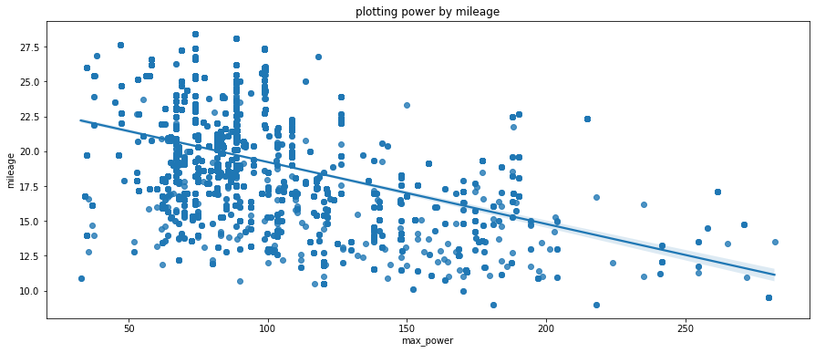

```python
#plotting the relationship between the mileage and the power of cars in the dataset
ax = plt.subplots(figsize=(15, 6))
sns.regplot(data =car, x="max_power", y='mileage')
plt.title('plotting power by mileage');
```

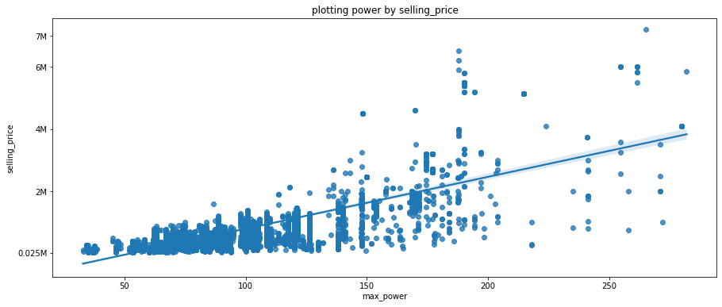

```python
#plotting the relationship between the selling price and car power
ax = plt.subplots(figsize=(15, 6))
sns.regplot(data=car, y="selling_price", x='max_power')
plt.yticks([25e3,2000e3,4000e3,6000e3,7000e3],['0.025M','2M','4M','6M','7M'])
plt.title('plotting power by selling_price');
```

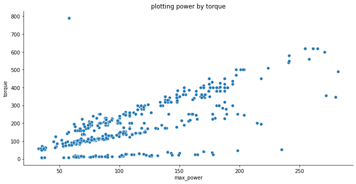

```python
# finding the relationship between the power and torque of the car
sns.relplot(data =car, x="max_power", y='torque', aspect=2)
plt.title('plotting power by torque');
```

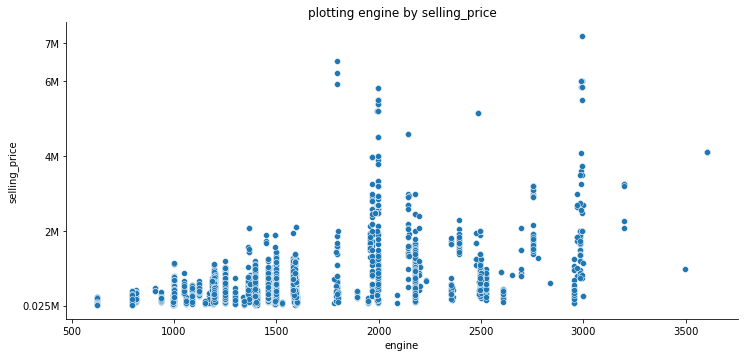

```python
#finding the relationship between the engine size and selling price
sns.relplot(data=car, x="engine", y='selling_price', aspect = 2)
plt.yticks([25e3,2000e3,4000e3,6000e3,7000e3],['0.025M','2M','4M','6M','7M'])
plt.title('plotting engine by selling_price');
```

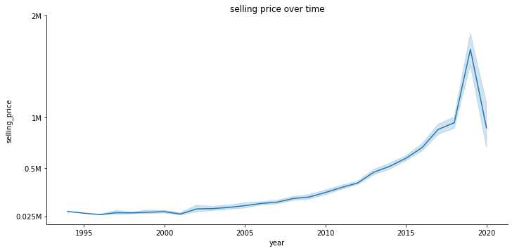

```python
#plotting the selling price over time
sns.relplot(data=car, x= 'year', y='selling_price',aspect = 2, kind= 'line')
plt.yticks([25e3,500e3,1000e3,2000e3],['0.025M','0.5M','1M','2M'])
plt.title('selling price over time');
```

```python
#defining a function to help plot distribution of numeric data over time
def plt1(var):
    sns.relplot(data=car, y=var, x='year',aspect = 2, kind= 'line')
    print('Title: trend of ' + var  + ' over time')
```

```
Title: trend of engine over time
```

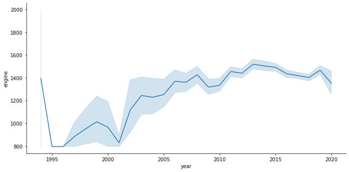

```python
#plotting engine size trend over time
plt1('engine')
```

```
Title: trend of max_power over time
```

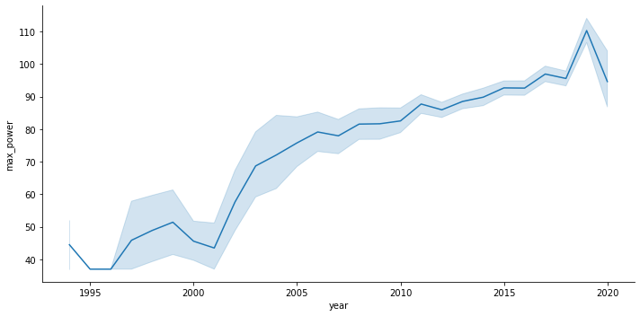

```python
#plotting the car power trend over time
plt1('max_power')
```

```
Title: trend of mileage over time
```

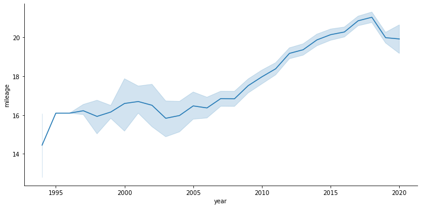

```python
#plotting the trend of mileage over time
plt1('mileage')
```

```
Title: trend of km_driven over time
```

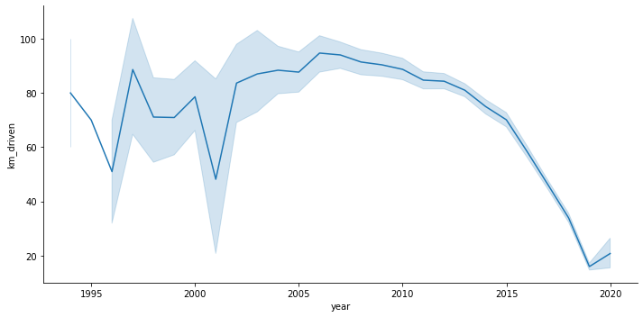

```python
#plotting the trend of total km driven over time
plt1('km_driven')
```

### Bivariant exploration of numeric-catogrical combination distribution

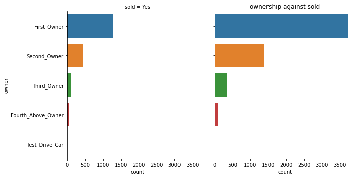

```python
#plotting the distrution of owners while comparing whether it was sold or not
sns.catplot(y= 'owner', kind='count', data = car, col= 'sold' )
plt.title('ownership against sold');
```

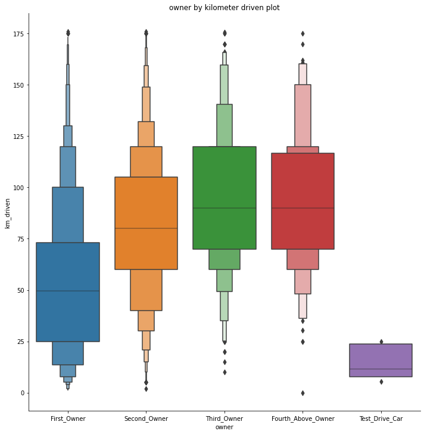

```python
#plotting to show ownership types over the owner types
sns.catplot( y= 'km_driven', x= 'owner', data =car,kind='boxen', height= 10)
plt.title('owner by kilometer driven plot');
```

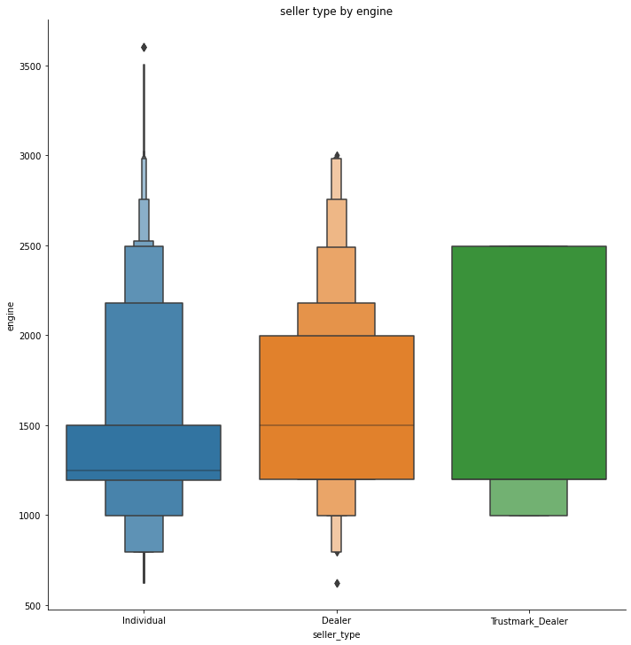

```python
#plotting to show engine size over the seller type
sns.catplot( y= 'engine', x= 'seller_type', data =car,  kind='boxen', height= 10)
plt.title('seller type by engine');
```

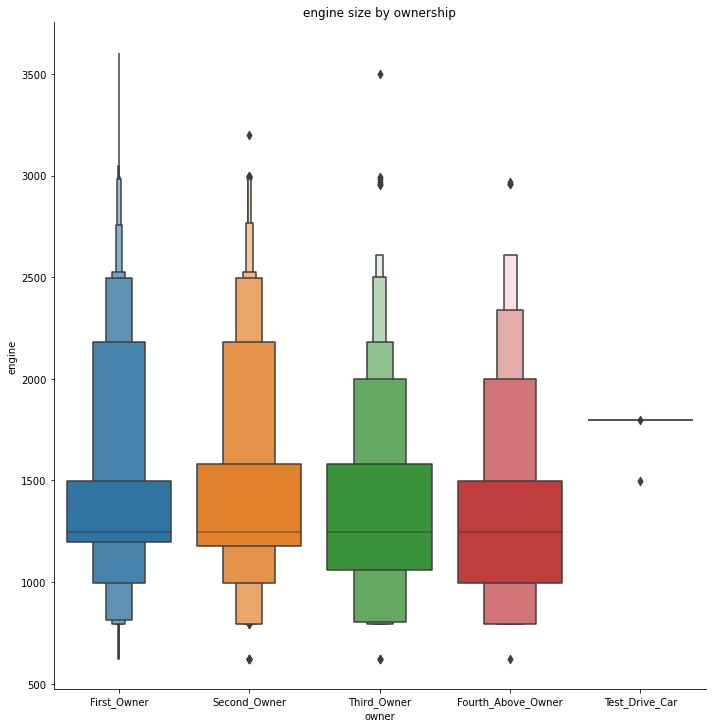

```python
#plotting to show engine size over the owner types
sns.catplot( y= 'engine', x= 'owner', data =car, kind='boxen', height= 10)
plt.title('engine size by ownership');
```

```python
#creating a fuction to plot a distribution of various non-numeric data against selling price
def plt_bivar(a):
    sns.catplot( y="selling_price", x= a, kind = 'boxen' , data =car, height = 10,aspect =1)
    plt.yticks([25e3,2000e3,4000e3,6000e3,7000e3],['0.025M','2M','4M','6M','7M']);
```

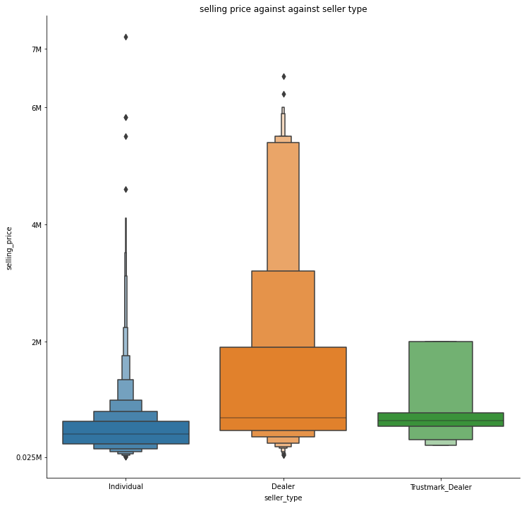

```python
#showing the  seller type over the price
plt_bivar('seller_type')
plt.title('selling price against against seller type');
```

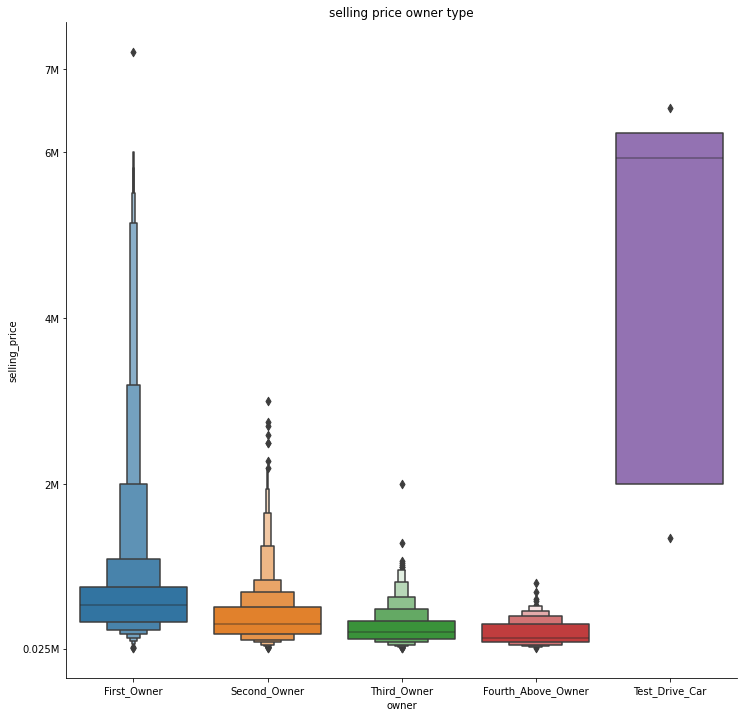

```python
#plotting show the distribution of owner type over the selling price
plt_bivar('owner')
plt.title('selling price owner type');
```

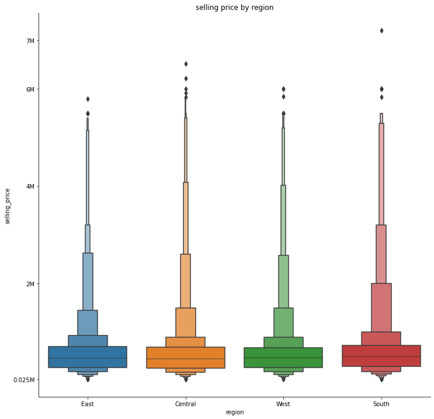

```python
#plotting region over selling price
plt_bivar('region')
plt.title('selling price by region');
```

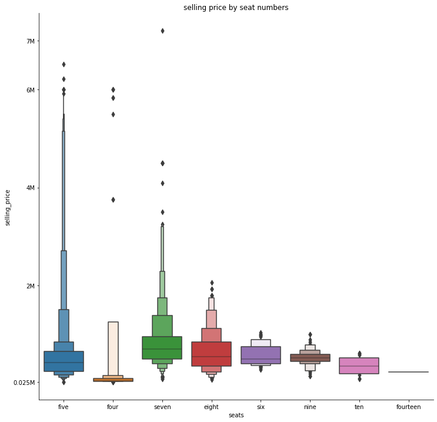

```python
#plotting the price distribution over the number of seats
plt_bivar('seats')
plt.title('selling price by seat numbers');
```

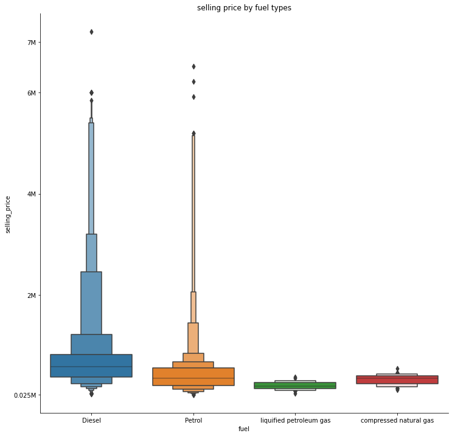

```python
#plotting the distribution of fuel types over the selling price
plt_bivar('fuel')
plt.title('selling price by fuel types')
```

### Talk about some of the relationships you observed in this part of the investigation. How did the feature(s) of interest vary with other features in the dataset?

> The dataset reveals that over time, the features of cars purchased increased, this include engine sizes, car power, mileage and selling price. However, the kilometer driven by car owners over the years reduced.

> The selling price of cars also increased as the engine size increases

> The dealer seller type of cars showed to be more expensive despite being the drastically lower in number than the individually sold cars. The cheapest are the individual-seller type of cars going as low as 26K in dollars.

> The Test_drive_cars also showed to be most expensive reaching about `$6m` although these cars are the least available in the dataset. The cheapest are the fourth-and-above owner type of cars

> The most expensive cars in relation to fuel type are the diesel-powered type of cars while following immediately in second place are the petrol-powered cars.

### Did you observe any interesting relationships between the other features (not the main feature(s) of interest)?

> There’s a strong correlation between `engine size` and `cars’ horsepower`. The cars with the highest engine sizes have the highest power. In other words, high engine sizes produce high horsepower

> The dataset also revealed that most of the cars are first-owner type of cars.

> Finally, the dataset reveal that cars already not sold out had greater distribution in most categorical variable than those sold out, in order words, they appeared appeared in greater amount than the cars sold out. This could explain why first_owner cars are greatest in number.

## Multivariate Exploration

```
Title : selling price by ownership by sold
```

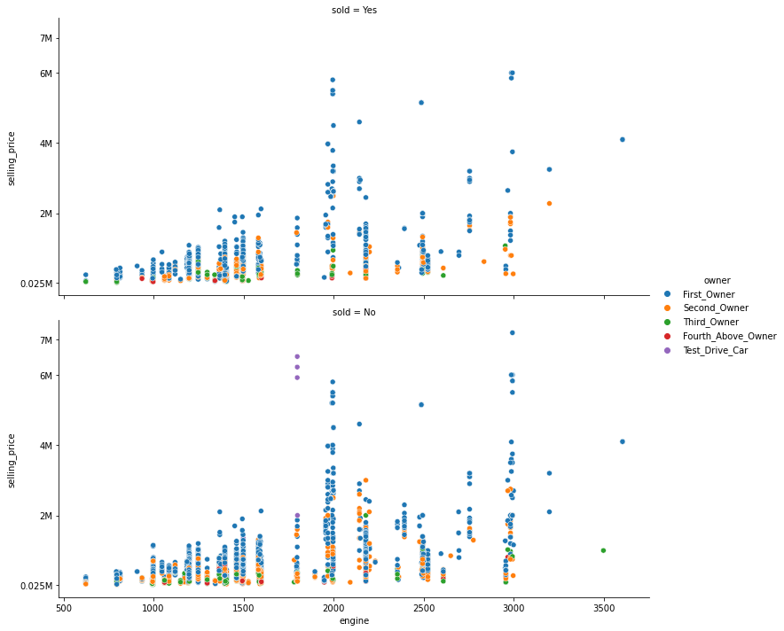

```python
#plotting engine size against selling price while comparing ownership and sold
sns.relplot( x="engine", y='selling_price', data = car, hue = 'owner',  row='sold', aspect=2)
plt.yticks([25e3,2000e3,4000e3,6000e3,7000e3],['0.025M','2M','4M','6M','7M'])
print('Title : selling price by ownership by sold');
```

```
Title : selling price by engine size by sold
```

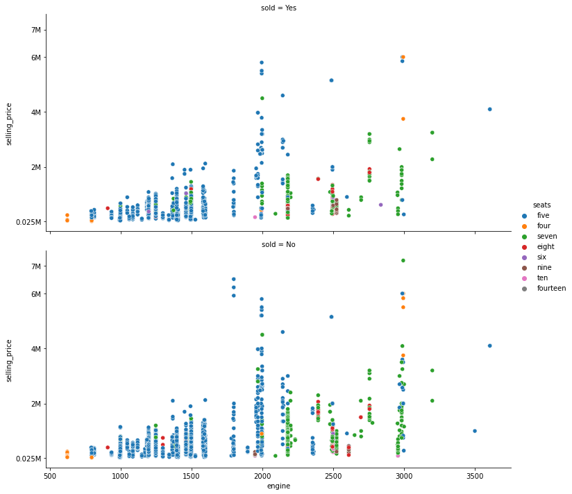

```python
#plotting engine size against selling price while comparing with sold or not
sns.relplot( x="engine", y='selling_price', data = car, hue = 'seats',  row='sold', aspect=2)
plt.yticks([25e3,2000e3,4000e3,6000e3,7000e3],['0.025M','2M','4M','6M','7M'])
print('Title : selling price by engine size by sold');
```

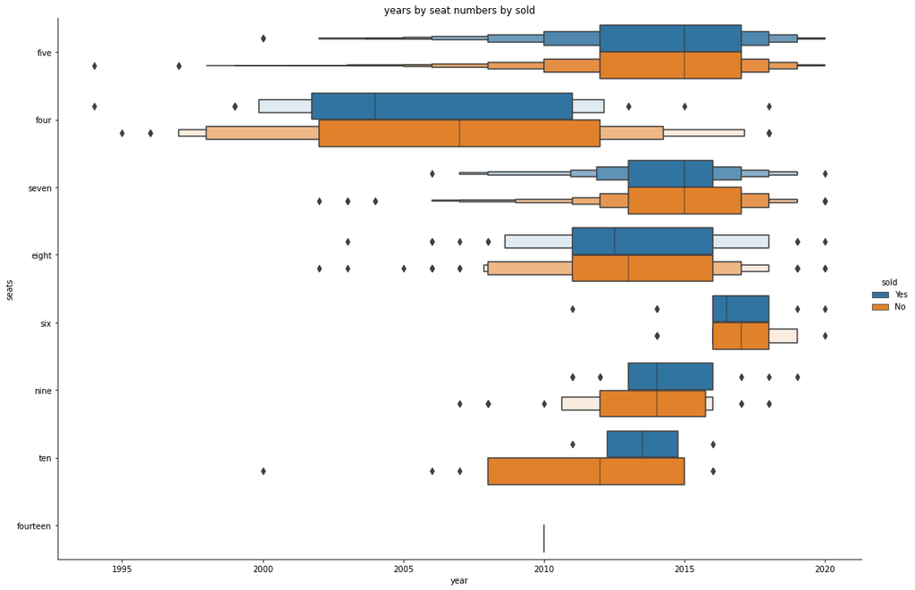

```python
#plotting the number of seats over the years with respect of sold or not
sns.catplot(data=car, x="year", y='seats',aspect = 1.5,height=10, kind='boxen',hue='sold')
plt.title('years by seat numbers by sold');
```

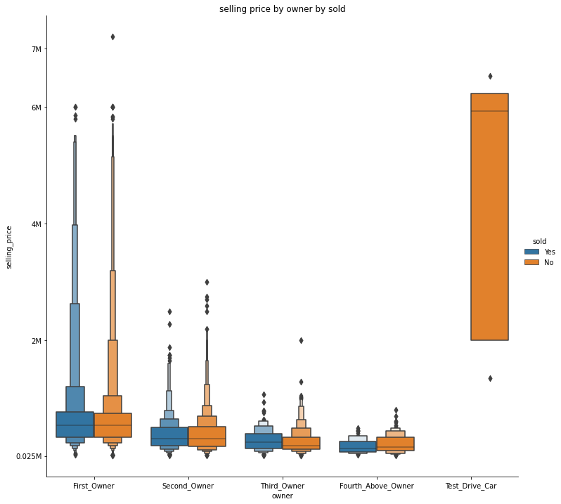

```python
#plotting the owner type against the selling price with respect to sold or not
sns.catplot( y="selling_price", x='owner', kind='boxen',data =car, hue='sold',height=10)
plt.yticks([25e3,2000e3,4000e3,6000e3,7000e3],['0.025M','2M','4M','6M','7M'])
plt.title('selling price by owner by sold');
```

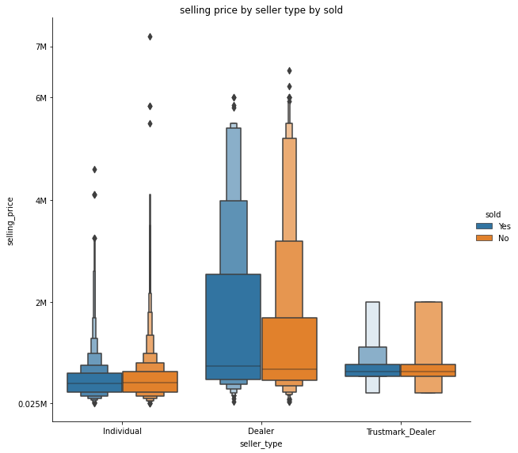

```python
#plotting seller type over selling price with respect to sold or not
sns.catplot( x="seller_type", y="selling_price", hue="sold", kind="boxen",  data = car, height=8)
plt.yticks([25e3,2000e3,4000e3,6000e3,7000e3],['0.025M','2M','4M','6M','7M'])
plt.title('selling price by seller type by sold');
```

```
Title : selling price by region and seat number by sold
```

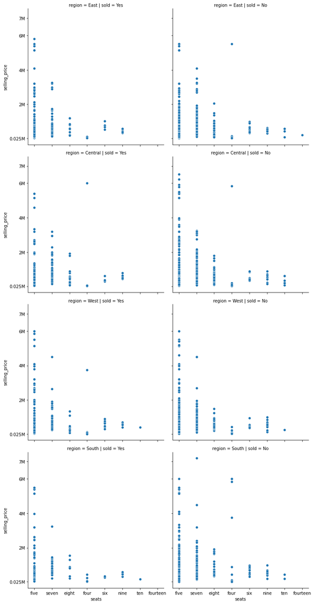

```python
#plotting the selling price for each region based on whether sales were made or not
sns.relplot(data = car, x = 'seats', y='selling_price', row = 'region', col= 'sold', );
plt.yticks([25e3,2000e3,4000e3,6000e3,7000e3],['0.025M','2M','4M','6M','7M'])
print('Title : selling price by region and seat number by sold');
```

```
Title: owner-type by seat numbers and whether sold or not
```

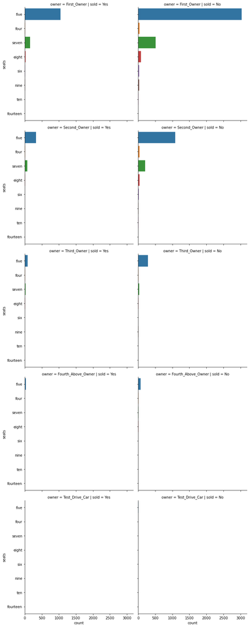

```python
#plotting a comparison of different seat numbers by different ownership
sns.catplot( data = car ,y='seats', kind = 'count', row='owner', col= 'sold')
print('Title: owner-type by seat numbers and whether sold or not');
```

```
count of sold or not by region
```

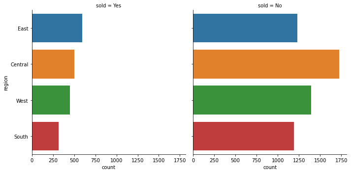

```
count of sold or not by owner
```

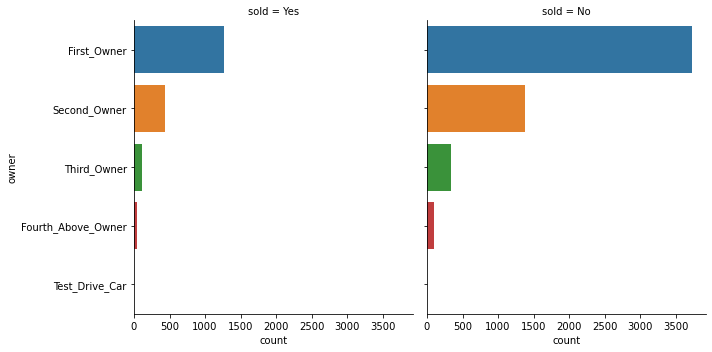

```
count of sold or not by seller_type
```

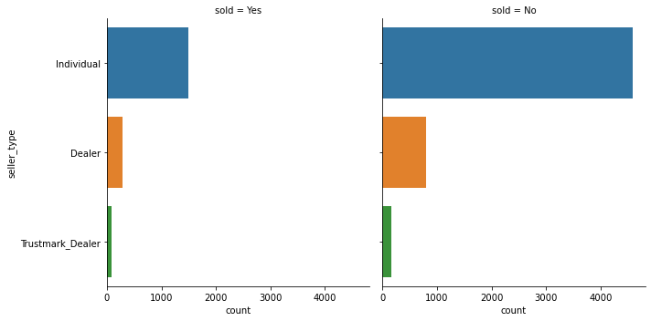

```
count of sold or not by transmission
```

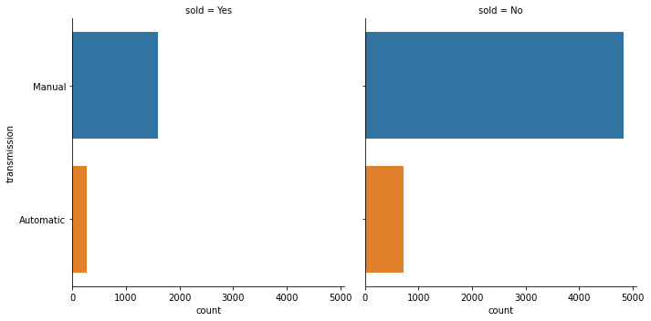

```
count of sold or not by fuel
```

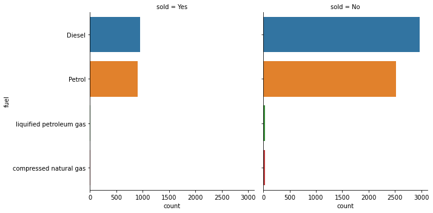

```
count of sold or not by seats
```

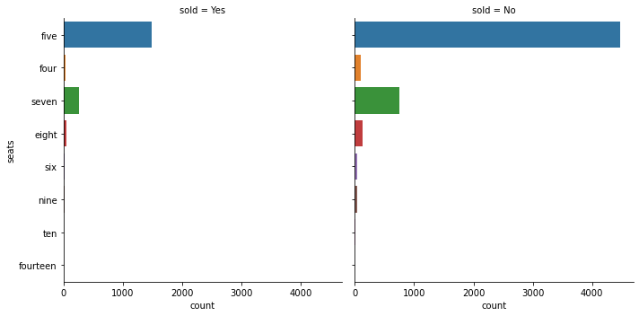

```python
#defining a fuction to plot non-numeric variables with respect to whether sold or not
def cat_plt2(a):
    print('count of sold or not by ' + a)
    sns.catplot(y= a, kind='count', data = car, col= 'sold' )
    plt.show();
#plotting for region
cat_plt2('region')

#plotting for owner
cat_plt2('owner')

#plotting for seller_type
cat_plt2('seller_type')

#plotting for transmission
cat_plt2('transmission')

#plotting for fuel
cat_plt2('fuel')

#plotting for seats
cat_plt2('seats')
```

```
Title: owner-type by seat numbers and region
```

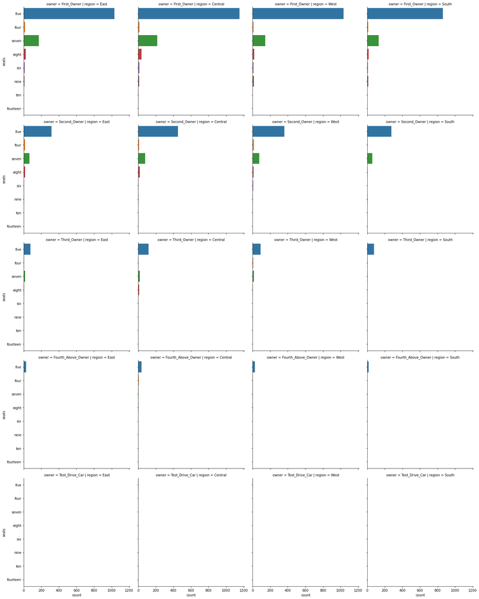

```python
#plotting a comparison of different seat numbers by different ownership and region
sns.catplot( data = car ,y='seats', kind = 'count', row='owner', col= 'region')
print('Title: owner-type by seat numbers and region');
```

```
Title: Selling price by Name by Sold while comparing quantity/count
```

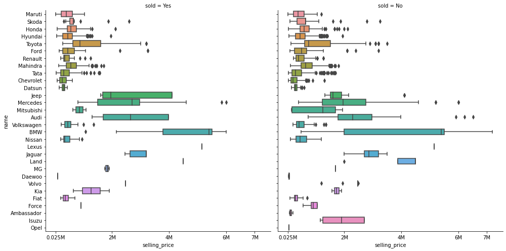

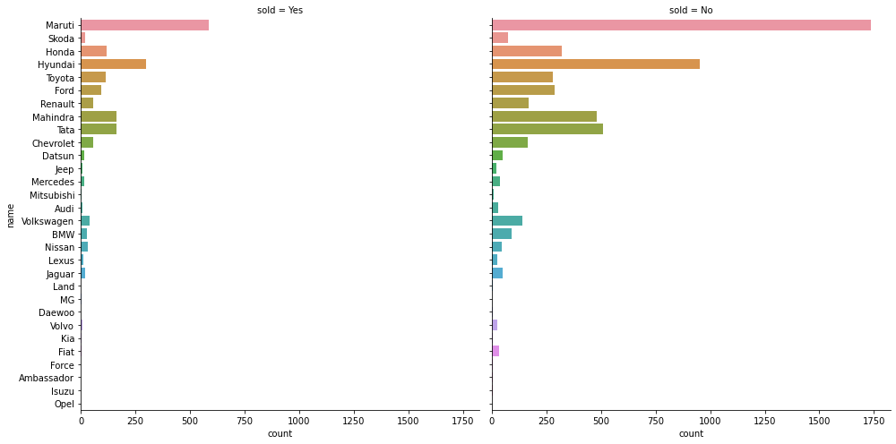

```python
#find a effect of price on different region comparing whether cars were sold or not meanwhile making an overall comparison with the
#distribution on each region (comparing a yes and no transaction as well.)
sns.catplot(x= 'selling_price', y= 'name', data = car, col= 'sold' , height= 7, kind= 'box' )
plt.xticks([25e3,2000e3,4000e3,6000e3,7000e3],
           ['0.025M','2M','4M','6M','7M'])
sns.catplot( y= 'name', data = car, col= 'sold' ,height= 7,kind = 'count' )
print('Title: Selling price by Name by Sold while comparing quantity/count');
```

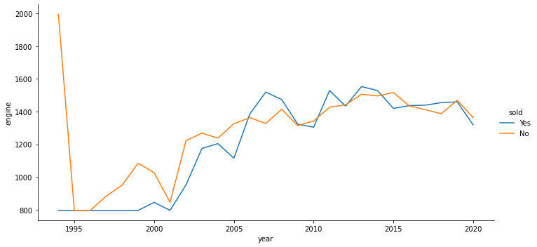

```python
#showing the engine for cars over the years in relation to sold
sns.relplot(data=car, x="year", y='engine',aspect = 2, kind= 'line', hue='sold', ci=None)
plt.title('engine size over time by sold');
```

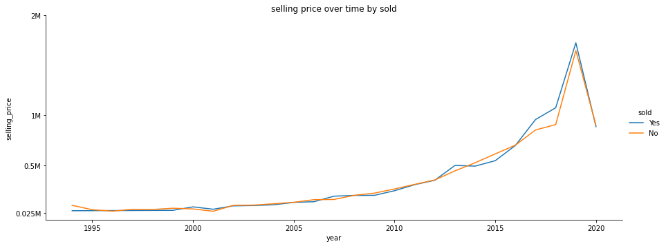

```python
#plotting to demostrate the selling price distribution over the years in relation to whether sale was made or not
sns.relplot(data=car, x="year", y='selling_price',aspect = 2.5, kind= 'line', hue= 'sold', ci=None)
plt.yticks([25e3,500e3,1000e3,2000e3],['0.025M','0.5M','1M','2M'])
plt.title('selling price over time by sold');
```

### Talk about some of the relationships you observed in this part of the investigation. Were there features that strengthened each other in terms of looking at your feature(s) of interest?

> During the multivariate the total number of cars not sold out is greater than those sold out in all variables and categories.

> The data also reveal that four-seater types of cars were purchase over a long time and those of them that have been sold out by their owners were only purchased within a short period of time.

> The data also reveals that although dealer seller-type cars are more expensive, the cars that have been sold are more expensive than the ones not sold.

> The four-seater vehicles are least expensive at the western region and most of them have not been sold. A prospect looking to buy four-seater car should look west.

### Were there any interesting or surprising interactions between features?

> Four-seater unsold vehicles for family use are cheapest in the West.

> Expensive cars are least available in the dataset and BMW vehicles are the most expensive and not sold out yet.

> None of the test_drive_cars (which are the most expensive type of cars in relation to car ownership) have been sold. Interestingly these cars have been driven a few kilometers below 25Km. These test-driven cars have engine sizes between 2000cc and 1500cc which is above the mean engine size.

## Conclusions

The `used_car` dataset contain a lot of explorable datapoints. The steps taken during the exploration were aimed at comparing the distribution of features of interest and other(supplementary) features. First, the distribution of the different data types; continuous, discrete and categorical data. Then, the bivariate exploration examined the nature of correlation between the mechanical features of the car as well as the distribution of these features over the categorical data. Finally at the multivariate exploration stage, the insights gotten from the bivariate exploration were used to further explore the additon of a third variable(both categorical and discrete).